# Sleep Case Study

Sarah Schwartz

12/22/2021

## Sleep Study Report

This is an example of a sleep report template using R Markdown. This template will automatically update all plots and statistics if new data if added.

## Sleep Duration Stastistics

| Statistics | Results |
| --- | --- |
| Mean | 7.26 |
| Standard Deviation | 1.47 |
| Variance | 2.18 |

# Plots

## Plotting a bar plot of sleep duration with different colors for the months

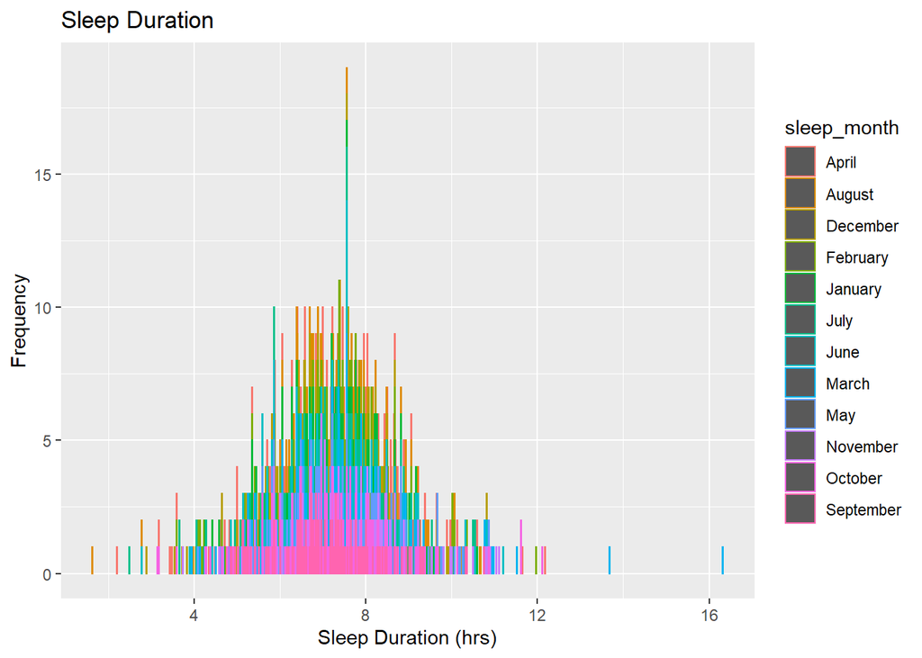

## Histogram with Normal Distribution Overlay

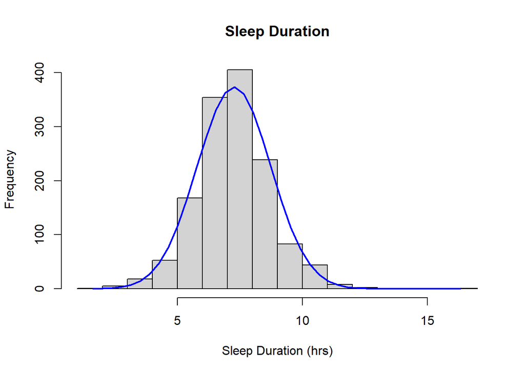

## Testing Normality of the data using the Shapiro-Wilk Test

This test will determine of the duration of sleep is consistent with a normal distribution. The hypothesis is that the data is consistent with a normal distribution. The results from the calculation is a p-value of 4.199e-10. Although the data may appear to be normally distributed when plotted as a histogram, the statistical test indicate that it is not consistent. This variation from the normal distribution, however, is much clearer when plotted in a Q-Q plot, as seen below.

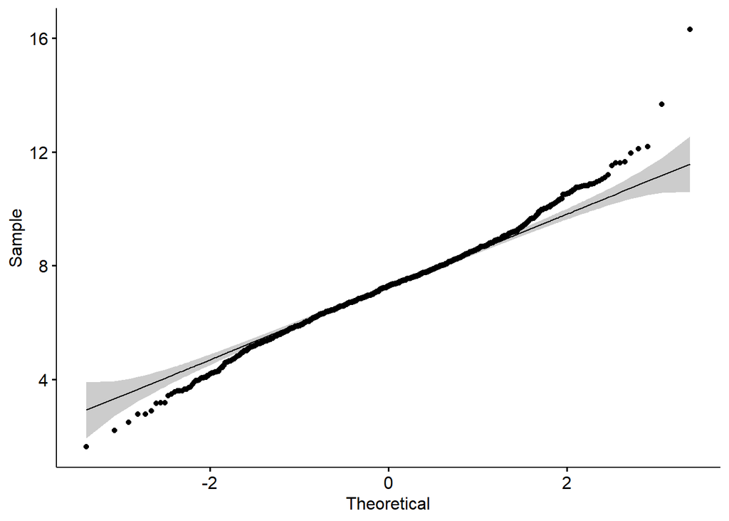